# Place of death in NRS COVID-19 deaths

## Load map data with `sf`

I previously downloaded shapefiles for:

- Local Authority Districts (LAD) for 2020 (BUC-level resolution): https://geoportal.statistics.gov.uk/datasets/local-authority-districts-may-2020-boundaries-uk-buc
- Health Boards https://data.gov.uk/dataset/27d0fe5f-79bb-4116-aec9-a8e565ff756a/nhs-health-boards
  - Note: this is a fairly high resolution, don’t need this much detail!
  - I found a discussion of this on [a github covid-related project](https://github.com/tomwhite/covid-19-uk-data/issues/18#issuecomment-622353841), and user **robchallen** produced a zip file containing [UK-wide health board boundaries](https://github.com/tomwhite/covid-19-uk-data/files/4563933/UK_covid_reporting_regions.zip)

```r
# shapefile_hb <- st_read(dsn = "./map_data/hb")  # too detailed!
shapefile_hb_uk_wide <- st_read(dsn = "./map_data/hb_uk_wide/UK_covid_reporting_regions")
shapefile_la <- st_read(dsn = "./map_data/la")
# merged_deaths_la %>%
#   filter(week_number==53 & place_of_death=="Home & other non-institution") %>%
#   left_join(shapefile_la,by=c("ref_area"="lad19nm")) %>%
#   ggplot(aes(fill = deaths_all_causes, geometry = geometry, group=ref_area)) +
#   geom_sf()
#
# merged_deaths_hb %>%
#   filter(week_number==53 & place_of_death=="Home & other non-institution") %>%
#   left_join(shapefile_hb_uk_wide,by=c("ref_area"="name")) %>%
#   ggplot(aes(fill = deaths_all_causes, geometry = geometry)) +
#   geom_sf() +
#   theme(aspect.ratio = 1.3)

# ggplot(data = shapefile_hb_uk_wide, aes(geometry=geometry)) + geom_sf()

## simple UK map
# ggplot(data = map_data(map = "world", region = "UK"), aes(x=long, y = lat, group = group)) +
#   geom_polygon() +
#   coord_map()
```

## Load COVID case counts by LA/HB

```r
files_case_counts <- set_names(x = as.list(table_of_case_trends_data_sources$path_latest), nm = table_of_case_trends_data_sources$short_name)

cases_hb <- read_csv(
  files_case_counts$hb,
  col_types =
    cols(
    .default = col_double(),
    `_id` = col_skip(),
    DailyDeaths = col_skip(),  # not needed, we get this elsewhere!
    Date = col_date(format = "%Y%m%d"),
    HB = col_character(),
    HBName = col_character(),
    HospitalAdmissionsQF = col_character(),
    ICUAdmissionsQF = col_character()
    ),
  ) %>% clean_names() %>%
  rename(ref_area = hb_name) %>%
  mutate(
    year = parse_integer(str_sub(ISOweek(date), start = 1, end = 4)),  # parse ISO year, otherwise the first few days of 2021 will belong to 2021 erroneously!
    week_number = parse_integer(str_sub(ISOweek(date), start = 7, end = 8)),
    ref_area = phsmethods::match_area(hb)  # convert to standard HB names
    )

cases_la <- read_csv(
  file = files_case_counts$la,
  col_types =
    cols(
    .default = col_double(),
    `_id` = col_skip(),
    DailyDeaths = col_skip(),  # not needed, we get this elsewhere!
    Date = col_date(format = "%Y%m%d"),
    CA = col_character(),
    CAName = col_character()
  )
) %>% clean_names() %>%
  rename(ref_area = ca_name) %>%
  mutate(
    year = parse_integer(str_sub(ISOweek(date), start = 1, end = 4)),  # parse ISO year, otherwise the first few days of 2021 will belong to 2021 erroneously!
    week_number = parse_integer(str_sub(ISOweek(date), start = 7, end = 8)),
    ref_area = phsmethods::match_area(ca)  # convert to standard LA names, jsut in case they weren't already!
    )
```

# Calculate case counts: weekly counts to match weekly death reporting

Note: the cumulative case counts have already been calculated, we just need to subset them to match the weeks. This is not trivial - the death counts cover an entire week starting from the “w/c date”; the cumulative cases for that week could be taken either at the start, the end of the week, or the start of the following week even!

However, when calculating weekly positive cases we can simply take the maximum of that week’s cumulative count - that will be the cumulative count at the end of the week!

Note also that the `crude_rate_positive_per100k` represents the cumulative rate!

```r
weekly_covid_cases_hb <-
  cases_hb %>%
  group_by(year, week_number, ref_area) %>%
  summarise(
    weekly_positive = sum(daily_positive),
    cumulative_positive = max(cumulative_positive),
    crude_rate_positive_per100k = max(crude_rate_positive),
    .groups = "drop"
  ) %>%
  mutate(
    date_w_c = compute_start_date_from_week_number(week_number = week_number, year = year),
    week_number_run_over = if_else(year == 2021, 53L + week_number, week_number)
    )

## extract Scotland-wide data and remove from HB split
weekly_covid_cases_overall <- weekly_covid_cases_hb %>% filter(ref_area=="Scotland")
weekly_covid_cases_hb <- weekly_covid_cases_hb %>% filter(ref_area!="Scotland")

weekly_covid_cases_la <-
  cases_la %>%
  group_by(year, week_number, ref_area) %>%
  summarise(
    weekly_positive = sum(daily_positive),
    cumulative_positive = max(cumulative_positive),
    crude_rate_positive_per100k = max(crude_rate_positive),
    .groups = "drop"
  ) %>%
  mutate(
    date_w_c = compute_start_date_from_week_number(week_number = week_number, year = year),
    week_number_run_over = if_else(year == 2021, 53L + week_number, week_number)
    )
```

# Comparing geographic areas by case counts

We can use the yearly cumulative case count to group geographic areas by how many cases they’ve had by the end of 2020.

[figure not shown]

```r
cumulative_case_2020_based_grouping_la <-
  weekly_covid_cases_la %>%
  filter(ref_area!="Scotland") %>%
  filter(year == 2020) %>%
  filter(week_number == max(week_number)) %>%  # keep last week
  select(ref_area, cumulative_positive, crude_rate_positive_per100k)

cumulative_case_2020_based_grouping_hb <-
  weekly_covid_cases_hb %>% filter(year == 2020) %>%
  filter(ref_area!="Scotland") %>%
  filter(year == 2020) %>%
  filter(week_number == max(week_number)) %>%  # keep last week
  select(ref_area, cumulative_positive, crude_rate_positive_per100k)

k_means_clustering_cases_and_per100k_2020_hb <- map(
  .x = 2:4,
  .f = ~kmeans(x=cumulative_case_2020_based_grouping_hb %>% select(cumulative_positive, crude_rate_positive_per100k), centers = .x, nstart = 1e3)
) %>% set_names(nm=paste0("k",2:4))

clusters_hb <-
  bind_cols(
    cumulative_case_2020_based_grouping_hb %>% select(ref_area),
    map_dfc(.x = k_means_clustering_cases_and_per100k_2020_hb, .f = function(x) return(x$cluster))
  )

cumulative_case_2020_based_grouping_hb <-
  cumulative_case_2020_based_grouping_hb %>%
  left_join(clusters_hb, by="ref_area") %>%
  mutate(
    quartiles_cases = ntile(cumulative_positive, n=4),
    quartiles_per100k = ntile(crude_rate_positive_per100k, n=4)
  )

# TODO: apply to LA also!


hb_cases_plots <- list()

hb_cases_plots$cumulative_cases_vs_per100k <-
  cumulative_case_2020_based_grouping_hb %>%
  ggplot(data=., aes(x=cumulative_positive, y=crude_rate_positive_per100k, label=ref_area)) +
  geom_point() +
  geom_label_repel() +
  theme_minimal() +
  labs(
    x="COVID cases",
    y="COVID cases per 100,000 population",
    title="Cases vs. population rate"
  ) +
  NULL

hb_cases_plots$cumulative_cases_vs_per100k_log10 <-
  cumulative_case_2020_based_grouping_hb %>%
  ggplot(data=., aes(x=cumulative_positive, y=crude_rate_positive_per100k, label=ref_area)) +
  geom_point() +
  geom_label_repel() +
  theme_minimal() +
  labs(
    x="COVID cases (log)",
    y="COVID cases per 100,000 population (log)",
    title="Cases vs. population rate (log scale axes)"
  ) +
  scale_x_log10() +
  scale_y_log10() +
  NULL

hb_cases_plots$cumulative_cases_vs_per100k_quartiles_cases <-
  cumulative_case_2020_based_grouping_hb %>%
  ggplot(data=., aes(x=cumulative_positive, y=crude_rate_positive_per100k, label=ref_area, shape=factor(quartiles_cases))) +
  geom_point(size=3, aes(colour=factor(quartiles_cases))) +
  scale_colour_viridis_d() +
  geom_label_repel() +
  theme_minimal() +
  labs(
    x="COVID cases",
    y="COVID cases per 100,000 population",
    title="Cases vs. population rate"
  ) +
  NULL

hb_cases_plots$cumulative_cases_vs_per100k_quartiles_cases <-
  cumulative_case_2020_based_grouping_hb %>%
  ggplot(data=., aes(x=cumulative_positive, y=crude_rate_positive_per100k, label=ref_area, shape=factor(quartiles_per100k))) +
  geom_point(size=3, aes(colour=factor(quartiles_cases))) +
  scale_colour_viridis_d() +
  geom_label_repel() +
  theme_minimal() +
  labs(
    x="COVID cases",
    y="COVID cases per 100,000 population",
    title="Cases vs. population rate",
    colour = "Quartile (Cases per 100,000)"
  ) +
  NULL

hb_cases_plots$cumulative_cases_vs_per100k_k2 <-
  cumulative_case_2020_based_grouping_hb %>%
  ggplot(data=., aes(x=cumulative_positive, y=crude_rate_positive_per100k, label=ref_area, shape=factor(k2))) +
  geom_point(size=3, aes(colour=factor(k2))) +
  scale_colour_viridis_d() +
  geom_label_repel() +
  theme_minimal() +
  labs(
    x="COVID cases",
    y="COVID cases per 100,000 population",
    title="Cases vs. population rate"
  ) +
  NULL


hb_cases_plots$cumulative_cases_vs_per100k_k3 <-
  cumulative_case_2020_based_grouping_hb %>%
  ggplot(data=., aes(x=cumulative_positive, y=crude_rate_positive_per100k, label=ref_area, shape=factor(k3))) +
  geom_point(size=3, aes(colour=factor(k3))) +
  scale_colour_viridis_d() +
  geom_label_repel() +
  theme_minimal() +
  labs(
    x="COVID cases",
    y="COVID cases per 100,000 population",
    title="Cases vs. population rate"
  ) +
  NULL


hb_cases_plots$cumulative_cases_vs_per100k_k4 <-
  cumulative_case_2020_based_grouping_hb %>%
  ggplot(data=., aes(x=cumulative_positive, y=crude_rate_positive_per100k, label=ref_area, shape=factor(k4))) +
  geom_point(size=3, aes(colour=factor(k4))) +
  scale_colour_viridis_d() +
  geom_label_repel() +
  theme_minimal() +
  labs(
    x="COVID cases",
    y="COVID cases per 100,000 population",
    title="Cases vs. population rate"
  ) +
  NULL


hb_cases_plots_assembled <- patchwork::wrap_plots(hb_cases_plots, ncol = 2)

hb_cases_plots_assembled
```

# Calculate historical averages, minima & maxima

Due to the counting of weeks, most years have 52 weeks with some years (2015 & 2020) having 53. Therefore we need to decide how to deal with week 53 in 2020 since only 2015 has a corresponding weekly count. The solution used here is to calculate a weekly rate for week 53 from week 53 in 2015, and week 52 in 2016-2019 - this represents the “last week of the year”, which includes December 31st.

```r
map2_dfr(
  .x = list(past_deaths_overall, past_deaths_hb, past_deaths_la, past_deaths_sex_age),
  .y = c("overall","health_board","council_area","sex_age"),
  .f = function(data_tbl, name) {
    data_tbl %>%
      mutate(dataset=name,year=as.numeric(year)) %>%
      filter(year %in% 2016:2019 & week_number==53) %>%
      count(dataset,year)
  }
) %>%
  pivot_wider(names_from=year,values_from=n) %>%
  knitr::kable(caption = "Number of entries by dataset for week number 53 in years 2016-2019 (which only had 52 weeks). Only the 'overall' historical deaths dataset has week 53 entries for years with 52 weeks, and all the entries are for 0 deaths.")
```

Number of entries by dataset for week number 53 in years 2016-2019 (which only had 52 weeks). Only the ‘overall’ historical deaths dataset has week 53 entries for years with 52 weeks, and all the entries are for 0 deaths.

| dataset | 2016 | 2017 | 2018 | 2019 |
| --- | --- | --- | --- | --- |
| overall | 5 | 5 | 5 | 5 |

```r
## helper function that creates week 53 data by taking week 52 in years with no year 53 and relabels it as 53
## CAUTION: only use this for computing averages! otherwise it's making up data that wasnae there
create_week_53_data_for_years_with_52_weeks <- function(data_tbl) {
  real_data <-
    data_tbl %>%
    filter(!(year %in% 2016:2019 & week_number==53))  # remove any entries for week 53 in years with 52 weeks - in some datasets they existed but had 0 listed
  fake_data <-
    data_tbl %>%
    filter(year %in% 2016:2019 & week_number==52) %>%
    mutate(week_number=53)
  return(
    bind_rows(
      real_data,
      fake_data
    )
  )
}

historical_average_overall <-
  past_deaths_overall %>%
  filter(year!="average") %>%  # remove averages
  group_by(year, week_number) %>%  # remove week 53 if it was 0 for all places  - this means there was no week 53!
  filter(!all(number_of_deaths==0 & week_number==53)) %>%
  ungroup %>%
  create_week_53_data_for_years_with_52_weeks %>%
  ungroup %>%
  group_by(week_number,place_of_death) %>%
  summarise(
    across(number_of_deaths, .fns = list(mean=mean,min=min,max=max)),
    .groups = "drop"
  ) %>% rename_all(~str_replace_all(.x, pattern = "number_of_deaths", replacement = "deaths"))


week_53_text <- "Due to the way ISO 8601 counts weeks, only 2015 in the 2015-2019 period had 53 weeks; averages for week 53 were computed from figures for week 53 in 2015 and week 52 for 2016-2019."

# TODO: weekly averages may be too detailed for this level od subcategorising!

historical_average_hb <-
  past_deaths_hb %>%
  create_week_53_data_for_years_with_52_weeks() %>%
  group_by(
    week_number, place_of_death, ref_area
  ) %>%
  summarise(
    deaths_mean = mean(number_of_deaths),
    deaths_min = min(number_of_deaths),
    deaths_max = max(number_of_deaths),
    .groups = "drop"
  )

historical_average_la <-
  past_deaths_la %>%
  create_week_53_data_for_years_with_52_weeks() %>%
  group_by(
    week_number, place_of_death, ref_area
  ) %>%
  summarise(
    deaths_mean = mean(number_of_deaths),
    deaths_min = min(number_of_deaths),
    deaths_max = max(number_of_deaths),
    .groups = "drop"
  )

historical_average_sex_age <-
  past_deaths_sex_age %>%
  create_week_53_data_for_years_with_52_weeks() %>%
  group_by(
    week_number, place_of_death, age, sex
  ) %>%
  summarise(
    deaths_mean = mean(number_of_deaths),
    deaths_min = min(number_of_deaths),
    deaths_max = max(number_of_deaths),
    .groups = "drop"
  )

historical_average_age <-
  past_deaths_age %>%
  create_week_53_data_for_years_with_52_weeks() %>%
  group_by(
    week_number, place_of_death, age
  ) %>%
  summarise(
    deaths_mean = mean(number_of_deaths),
    deaths_min = min(number_of_deaths),
    deaths_max = max(number_of_deaths),
    .groups = "drop"
  )

historical_average_sex <-
  past_deaths_sex %>%
  create_week_53_data_for_years_with_52_weeks() %>%
  group_by(
    week_number, place_of_death, sex
  ) %>%
  summarise(
    deaths_mean = mean(number_of_deaths),
    deaths_min = min(number_of_deaths),
    deaths_max = max(number_of_deaths),
    .groups = "drop"
  )

compute_historical_annual_average_deaths <- function(data_tbl, ...) {
  grouping_vars <- enquos(...)
  data_tbl %>%
    group_by(year, place_of_death, !!!grouping_vars) %>%
    summarise(  # calculate annual totals first...
    number_of_deaths = sum(number_of_deaths),
    .groups = "keep"
  ) %>%
  ungroup(year) %>%  # remove year as grouping to average over year now
  summarise(
    annual_deaths_mean = mean(number_of_deaths),
    annual_deaths_min = min(number_of_deaths),
    annual_deaths_max = max(number_of_deaths),
    .groups = "drop"
  )
}


historical_annual_average_overall <-
  past_deaths_overall %>%
  compute_historical_annual_average_deaths()

historical_annual_average_hb <-
  past_deaths_hb %>%
  compute_historical_annual_average_deaths(ref_area)

historical_annual_average_la <-
  past_deaths_la %>%
  compute_historical_annual_average_deaths(ref_area)

historical_annual_average_sex_age <-
  past_deaths_sex_age %>%
  compute_historical_annual_average_deaths(sex, age)

historical_annual_average_sex <-
  past_deaths_sex %>%
  compute_historical_annual_average_deaths(sex)

historical_annual_average_age <-
  past_deaths_age %>%
  compute_historical_annual_average_deaths(age)
```

## Check weekly historic averages against NRS computed data

```r
weekly_deaths_overall %>%
  filter(sex=="all" & age=="all") %>%
  left_join(historical_average_overall) %>%
  select(year, week_number, place_of_death, deaths_nrs_past_average_all_causes, deaths_mean) %>%
  filter(round(deaths_nrs_past_average_all_causes) != round(deaths_mean)) %>%
  knitr::kable(caption = "Subset of weekly deaths where calculated mean deaths 2015-2019 differed between the COVID-19 related deaths file and the weekly deaths file (i.e. all other entries had the same figures!). Week 53 was computed as the average of deaths in week 53 in 2015 and week 52 in 2016-2019. For all the other datasets the mean deaths computed agree!")
```

Subset of weekly deaths where calculated mean deaths 2015-2019 differed between the COVID-19 related deaths file and the weekly deaths file (i.e. all other entries had the same figures!). Week 53 was computed as the average of deaths in week 53 in 2015 and week 52 in 2016-2019. For all the other datasets the mean deaths computed agree!

| year | week_number | place_of_death | deaths_nrs_past_average_all_causes | deaths_mean |
| --- | --- | --- | --- | --- |
| 2020 | 53 | All | 1018 | 1075.4 |

# Calculate moving averages (rolling mean) over multiple weeks

Once data are broken down by region there are very small figures on a weekly basis, so we can compute a moving average over several weeks instead. This is different to merging figures into 2-week chunks, for example, as information from consecutive weeks will overlap.

The average will be computed to the “left” of the current value (a week’s moving average is the average of values at this week + n-1 past weeks, or “right” aligned).

Moving averages for historical data will be computed over the previously computed weekly means & ranges. Computing moving averages over historical ranges produces wider spread data than computing ranges of moving averages (see `order_of_min_max_rolling_mean.R`).

```r
weeks_to_average <- 2

## compute moving average over weekly data, using average over k weeks
## using historical data to compute the moving average in the first few weeks of current data
## Note: historical data needs to be the non-summarised (raw) data!
## to compute moving average in first few week(s) of year, we add in the previous years' data and code the weeks so that they retain the right order
## i.e. in 2020 the week_number_run_over starts at 1, and the last week of 2019 is coded as 0, the 2nd last as -1, etc.
## once the moving average has been computed, we remove the past data;
## this approach works for 2021 data seamlessly, using the last weeks of 2020 for the moving average in 2021!
compute_moving_average_for_current_data <- function(current_data, historical_data) {
  bind_rows(
    historical_data %>%  # add historical data and format it so that it matches current data
      filter(year == 2019) %>%  # keep only last year before 2020
      rename(deaths_all_causes = number_of_deaths) %>%  # in historical deaths there is no split between covid/non-covid so we rename to all cause deaths
      mutate(week_number_run_over = -(52-week_number)),
    current_data
  ) %>%
    arrange(week_number_run_over) %>%  # just in case the order got messed up, re-order by week_number_run_over for the computation
    group_by_all() %>% ungroup(matches("^deaths_|week|date|year")) %>%  # clever way of getting grouping by ref_area, sex, age, whatever is available
    mutate(across(
        .cols = matches("^deaths_"),
        .fns = ~zoo::rollmean(.x, k=weeks_to_average, fill=NA, align="right"),
        .names = "ma{weeks_to_average}w_{.col}"
        )
    ) %>%
    ungroup %>%
    filter(year > 2019)  # keep only current data
}

rolling_deaths_hb <-
  compute_moving_average_for_current_data(current_data = weekly_deaths_hb, historical_data = past_deaths_hb)

rolling_deaths_la <-
  compute_moving_average_for_current_data(current_data = weekly_deaths_la, historical_data = past_deaths_la)

rolling_deaths_sex_age <-
  compute_moving_average_for_current_data(current_data = weekly_deaths_sex_age, historical_data = past_deaths_sex_age)

rolling_deaths_age <-
  compute_moving_average_for_current_data(current_data = weekly_deaths_age, historical_data = past_deaths_age)

rolling_deaths_sex <-
  compute_moving_average_for_current_data(current_data = weekly_deaths_sex, historical_data = past_deaths_sex)



## inspect the calculations
rolling_deaths_la %>% filter(week_number_run_over %in% c(1:3,52:54) & str_detect(ref_area,"Glasgow") & place_of_death=="Hospital") %>% select(year, week_number_run_over, ref_area, place_of_death, deaths_all_causes, ma2w_deaths_all_causes) %>% knitr::kable(caption="Showing how rolling average was computed: week 1 is average of week 52 of 2019 (not shown) and week 1 of 2020; week 2 is average of weeks 1 & 2, etc.")
```

Showing how rolling average was computed: week 1 is average of week 52 of 2019 (not shown) and week 1 of 2020; week 2 is average of weeks 1 & 2, etc.

| year | week_number_run_over | ref_area | place_of_death | deaths_all_causes | ma2w_deaths_all_causes |
| --- | --- | --- | --- | --- | --- |
| 2020 | 1 | Glasgow City | Hospital | 78 | 67.0 |
| 2020 | 2 | Glasgow City | Hospital | 59 | 68.5 |
| 2020 | 3 | Glasgow City | Hospital | 70 | 64.5 |
| 2020 | 52 | Glasgow City | Hospital | 71 | 64.5 |
| 2020 | 53 | Glasgow City | Hospital | 75 | 73.0 |
| 2021 | 54 | Glasgow City | Hospital | 88 | 81.5 |

```r
rolling_deaths_sex_age %>% filter(week_number_run_over %in% c(1:3,52:54) & str_detect(sex,"F") & age == "65-74" & place_of_death=="Hospital") %>% select(year, week_number_run_over, sex, age, place_of_death, deaths_all_causes, ma2w_deaths_all_causes) %>% knitr::kable(caption = "Showing how rolling average was computed: week 1 is average of week 52 of 2019 (not shown) and week 1 of 2020; week 2 is average of weeks 1 & 2, etc.")
```

Showing how rolling average was computed: week 1 is average of week 52 of 2019 (not shown) and week 1 of 2020; week 2 is average of weeks 1 & 2, etc.

| year | week_number_run_over | sex | age | place_of_death | deaths_all_causes | ma2w_deaths_all_causes |
| --- | --- | --- | --- | --- | --- | --- |
| 2020 | 1 | F | 65-74 | Hospital | 40 | 43.5 |
| 2020 | 2 | F | 65-74 | Hospital | 69 | 54.5 |
| 2020 | 3 | F | 65-74 | Hospital | 57 | 63.0 |
| 2020 | 52 | F | 65-74 | Hospital | 39 | 46.0 |
| 2020 | 53 | F | 65-74 | Hospital | 56 | 47.5 |
| 2021 | 54 | F | 65-74 | Hospital | 67 | 61.5 |

```r
## helper function that takes historical data and computes a moving average over k weeks
## with the additional trick of using the last week of all the years as the week prior to the first week
## strictly speaking we should be using the last week(s) of 2014 to compute the moving average for the first week(s) in 2015, depending on k; and we shouldn't be using the last week of 2019 in the computation either
## however, the overall effect of this is small since we're averaging over the entire 2015-2019 period
## the inaccuracy of this approach increases with increasing k
## the solution for fixing this is straightforward - just download 2014 data as well, and merge the "current" data and the historical data, and then perform the moving average calculation as usual
compute_moving_average_for_historical_data <- function(historical_data) {
  last_week_in_previous_year_required <- 53 + 2 - weeks_to_average  # this computes the last week needed from the previous year: if averaging over 2 weeks, we need week 3, if over 3 weeks, the lat week needed is 52, etc.
  bind_rows(
    historical_data %>%  # keep last week from all years and convert it to week 0
      filter(week_number %in% last_week_in_previous_year_required:53) %>%
      mutate(week_number = week_number - 53),  # set week number for data in previous to negative numbers but retaining order
    historical_data
  ) %>%
  arrange(week_number) %>%  # sort in ascending order of week_number
  group_by_all() %>% ungroup(matches("^deaths_"),week_number) %>%
  mutate(across(
      .cols = matches("^deaths_"),
      .fns = ~zoo::rollmean(.x, k=weeks_to_average, fill=NA, align="right"),
      .names = "ma{weeks_to_average}w_{.col}"
      )
  ) %>%
  ungroup %>%
  filter(week_number!=0)
}

historical_average_hb <- compute_moving_average_for_historical_data(historical_average_hb)
historical_average_la <- compute_moving_average_for_historical_data(historical_average_la)
historical_average_sex_age <- compute_moving_average_for_historical_data(historical_average_sex_age)
historical_average_sex <- compute_moving_average_for_historical_data(historical_average_sex)
historical_average_age <- compute_moving_average_for_historical_data(historical_average_age)
```

# Merge weekly COVID/non-COVID-related deaths in 2020/2021 with historic death rates

```r
## compute rolling average
merged_deaths_overall <-
  weekly_deaths_overall %>%
  filter(sex=="all" & age=="all") %>%
  inner_join(historical_average_overall %>% mutate(sex = "all", age = "all"),  # only merge for aggregated data b/c that's all we have!
            by = c("place_of_death", "week_number", "sex", "age"))

merged_deaths_hb <-
  rolling_deaths_hb %>%  # use data with rolling movingincluded
  inner_join(historical_average_hb, by = c("week_number","ref_area","place_of_death"))

merged_deaths_la <-
  rolling_deaths_la %>%  # use data with rolling movingincluded
  inner_join(historical_average_la, by = c("week_number","ref_area","place_of_death"))

merged_deaths_sex_age <-
  rolling_deaths_sex_age %>%  # use data with rolling movingincluded
  inner_join(historical_average_sex_age, by = c("place_of_death", "week_number", "sex", "age"))

merged_deaths_sex <-
  rolling_deaths_sex %>%
  inner_join(historical_average_sex, by = c("place_of_death", "week_number", "sex"))

merged_deaths_age <-
  rolling_deaths_age %>%
  inner_join(historical_average_age, by = c("place_of_death", "week_number", "age"))
```

# Annual deaths for 2020 & 2021

For visualising data using maps, we need to compute data for the entire year. Note: the non-covid and covid-related deaths in 2020 don’t add up to all cause deaths due to the covid status only starting in week 12!

```r
compute_total_deaths_in_year <- function(data_tbl, ...) {
  grouping_vars <- enquos(...)
  data_tbl %>%
    group_by(year, place_of_death, !!!grouping_vars) %>%
    summarise(across(.cols = c(deaths_all_causes, deaths_covid_related, deaths_non_covid), .fns = ~sum(.x,na.rm=TRUE)), .groups = "drop") %>%  # compute sums of all types of death
    mutate(deaths_all_causes_since_covid = deaths_covid_related + deaths_non_covid)  # compute a smaller number of all-cause deaths since covid started (over 2020, covid- and non-covid-related deaths don't add up to all-cause deaths because pre-covid deaths are included also!)
}

compute_ratio_of_annual_deaths_to_historical <- function(data_tbl) {
  data_tbl %>%
    mutate(
      ratio_annual_deaths_to_historical_mean = deaths_all_causes / annual_deaths_mean,
      ratio_annual_deaths_to_historical_min = deaths_all_causes / annual_deaths_min,
      ratio_annual_deaths_to_historical_max = deaths_all_causes / annual_deaths_max
    )
}

total_deaths_la <-
  merged_deaths_la %>%
  compute_total_deaths_in_year(ref_area) %>%
  left_join(historical_annual_average_la, by = c("place_of_death", "ref_area")) %>%
  compute_ratio_of_annual_deaths_to_historical

total_deaths_hb <-
  merged_deaths_hb %>%
  compute_total_deaths_in_year(ref_area) %>%
  left_join(historical_annual_average_hb, by = c("place_of_death", "ref_area")) %>%
  compute_ratio_of_annual_deaths_to_historical

total_deaths_sex <-
  merged_deaths_sex %>%
  compute_total_deaths_in_year(sex) %>%
  left_join(historical_annual_average_sex, by = c("place_of_death", "sex")) %>%
  compute_ratio_of_annual_deaths_to_historical

total_deaths_age <-
  merged_deaths_age %>%
  compute_total_deaths_in_year(age) %>%
  left_join(historical_annual_average_age, by = c("place_of_death", "age")) %>%
  compute_ratio_of_annual_deaths_to_historical

total_deaths_overall <-
  merged_deaths_overall %>%
  compute_total_deaths_in_year() %>%
  left_join(historical_annual_average_overall, by = c("place_of_death")) %>%
  compute_ratio_of_annual_deaths_to_historical
```

# Comparisons of annual rates with current rates

```r
## this is fairly ad-hoc... but it works!
table_comparing_rates <-
  bind_rows(
    ## all available data
    merged_deaths_overall %>%
      filter(age == "all" &
               sex == "all" &
               str_starts(place_of_death, "Home")) %>% group_by(year, week_number) %>%
      summarise(
        deaths_all_causes = sum(deaths_all_causes),
        deaths_non_covid = sum(deaths_non_covid, na.rm = TRUE),
        deaths_covid_related = sum(deaths_covid_related, na.rm = TRUE),
        .groups = "drop"
      ) %>% left_join(
        past_deaths_overall %>% filter(str_starts(place_of_death, "Home") &
                                         year != "average") %>% group_by(week_number) %>% summarise(
                                           average_weekly_deaths = sum(number_of_deaths) / 5,
                                           .groups = "drop"
                                         ),
        by = "week_number"
      ) %>% summarise(
        period = "all available data",
        deaths_all_causes = sum(deaths_all_causes),
        deaths_non_covid = sum(deaths_non_covid, na.rm = TRUE),
        deaths_covid_related = sum(deaths_covid_related, na.rm = TRUE),
        past_annual_deaths = sum(average_weekly_deaths)
      )
    ,
    ## 2020 only
    bind_cols(
      merged_deaths_overall %>%
        filter(
          age == "all" &
            sex == "all" & str_starts(place_of_death, "Home") & year == 2020
        ) %>%
        summarise(
          period = "2020",
          deaths_all_causes = sum(deaths_all_causes),
          deaths_non_covid = sum(deaths_non_covid, na.rm = TRUE),
          deaths_covid_related = sum(deaths_covid_related, na.rm = TRUE)
        ),
      past_deaths_overall %>% filter(str_starts(place_of_death, "Home") &
                                       year != "average") %>% summarise(past_annual_deaths = sum(number_of_deaths) / 5)
    ),
    ## 2020 from week 12 onwards (including week 12) - pandemic part of 2020
    bind_cols(
      merged_deaths_overall %>%
        filter(
          age == "all" &
            sex == "all" &
            str_starts(place_of_death, "Home") &
            year == 2020 & week_number >= 12
        ) %>%
        summarise(
          period = "2020, from wk12",
          deaths_all_causes = sum(deaths_all_causes),
          deaths_non_covid = sum(deaths_non_covid, na.rm = TRUE),
          deaths_covid_related = sum(deaths_covid_related, na.rm = TRUE)
        ),
      past_deaths_overall %>% filter(
        week_number >= 12 &
          str_starts(place_of_death, "Home") &
          year != "average"
      ) %>% summarise(past_annual_deaths = sum(number_of_deaths) / 5)
    )
  ) %>%
  mutate(
    ratio_deaths_all_causes_to_historical = deaths_all_causes / past_annual_deaths,
    ratio_non_covid_deaths_to_historical = deaths_non_covid / past_annual_deaths,
    proportion_covid_deaths = deaths_covid_related / deaths_all_causes
  )

write_csv(x = table_comparing_rates, file = file.path(dir_outputs, "annual_death_rates_comparison_with_historical_deaths.csv"))

table_comparing_rates %>% knitr::kable(caption = "Comparing annual home death rate during COVID pandemic to historical deaths at home")
```

Comparing annual home death rate during COVID pandemic to historical deaths at home

| period | deaths_all_causes | deaths_non_covid | deaths_covid_related | past_annual_deaths | ratio_deaths_all_causes_to_historical | ratio_non_covid_deaths_to_historical | proportion_covid_deaths |
| --- | --- | --- | --- | --- | --- | --- | --- |
| all available data | 23699 | 19349 | 570 | 17461.2 | 1.357238 | 1.108114 | 0.0240516 |
| 2020 | 20756 | 16563 | 413 | 15445.6 | 1.343813 | 1.072344 | 0.0198979 |
| 2020, from wk12 | 16976 | 16563 | 413 | 11851.6 | 1.432380 | 1.397533 | 0.0243285 |

# Comparing historical rates of home death to total death to 2020/2021

```r
proportions_of_historical_deaths_by_place <-
  past_deaths_overall %>%
  group_by(year, place_of_death) %>% summarise(number_of_deaths = sum(number_of_deaths), .groups="drop") %>%
  filter(place_of_death != "All" & !is.na(as.integer(year))) %>%
  group_by(year) %>%
  mutate(
    total_deaths = sum(number_of_deaths)
  ) %>%
  ungroup %>%
  mutate(proportion_of_total = number_of_deaths / total_deaths, year=as.integer(year))
proportions_of_current_deaths_by_place <-
  total_deaths_overall %>%
  select(year, place_of_death, number_of_deaths = deaths_all_causes) %>%
  filter(place_of_death != "All") %>%
  group_by(year) %>%
  mutate(
    total_deaths = sum(number_of_deaths)
  ) %>%
  ungroup %>%
  mutate(proportion_of_total = number_of_deaths / total_deaths)

merged_proportions_of_deaths_by_place <-
  bind_rows(
    proportions_of_historical_deaths_by_place,
    proportions_of_current_deaths_by_place
  )
```

# Visualisations

## Common elements

```r
theme_set(theme_minimal(base_size = 16) +
            theme(panel.grid.minor = element_blank(),
                  axis.title.y = element_text(margin = margin(0, 20, 0, 0)),  # remove gap to the left of y axis title and below the x axis title
                  axis.title.x = element_text(margin = margin(20, 0, 0, 0))
            ))


date_range_text <- glue::glue("Data from w/c {format(min(weekly_deaths_overall$date_w_c), '%d %B %Y')} to w/c {format(max(weekly_deaths_overall$date_w_c), '%d %B %Y')} (inclusive).")

dashed_line_historical_range_text <- "Range of deaths 2015-19 shown as shaded area; mean shown as dashed line."

only_2020_text <- glue::glue("Data from 2020 included, starting with w/c {format(min(merged_deaths_age$date_w_c))}.")
only_2021_text <- glue::glue("Data for 2021 only include weeks 1-{format(max(merged_deaths_age$week_number[merged_deaths_age$year==2021]))} (w/c {format(max(merged_deaths_age$date_w_c))}).")

source_nrs_text <- "Source: National Records of Scotland"
source_phs_text <- "Source: Public Health Scotland"

death_registrations_text <- "Note: all figures are based on date of registration."

vertical_line_text <- "Vertical dotted line at week number 54 represents start of 2021."
```

# Proportion home deaths over time

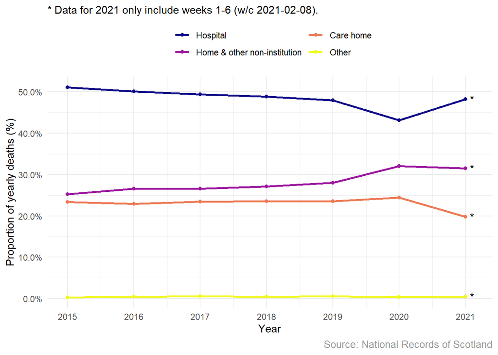

```r
figure_proportion_home_deaths_over_time <-
  merged_proportions_of_deaths_by_place %>%
  mutate(place_of_death = factor(x = place_of_death, levels = order_of_place_of_death_levels[c(1,3,2,4)])) %>%  # move home to 2nd position to match order in plot
  ggplot(., aes(x=year, y=proportion_of_total, colour=place_of_death)) +
  geom_point() +
  geom_line(size = 1) +
  geom_text(data = ~filter(.x, year==2021), aes(x=2021.1, y=proportion_of_total, label="*"), inherit.aes = FALSE) +
  scale_x_continuous(breaks = 2015:2021) +
  scale_y_continuous(label = scales::percent) +
  scale_colour_viridis_d(option="C") +
  theme_minimal() +
  theme(legend.position = "top", plot.caption = element_text(size = 10, colour = "gray60")) +
  labs(
    x = "Year", y= "Proportion of yearly deaths (%)",
    colour = "",
    subtitle = paste0("* ",only_2021_text),
    caption = paste0(c(source_nrs_text),collapse="\n")
    ) +
  guides(colour = guide_legend(nrow=2)) +  # spread colour legend over two rows
  NULL

walk(
  .x = c(".pdf",".svg",".png"),
  .f = ~ggsave(filename = paste0(dir_outputs,"/figure_proportion_home_deaths_over_time",.x), plot = figure_proportion_home_deaths_over_time, width = 12, height = 10, units = "cm", dpi = 300)
)

figure_proportion_home_deaths_over_time
```

# Number of deaths visualisations

## Number of deaths by age group

[figure not shown]

```r
## graph format copied from: https://github.com/davidhen/nrs_covid_stats/
weekly_deaths_overall %>%
  filter(sex == "all" & place_of_death == "All") %>%
  filter(age != "all") %>%
  group_by(age) %>%
  summarise(n = sum(deaths_all_causes)) %>%
  mutate(pct = round(n/sum(n), 3)) %>%
  ggplot(aes(age, n)) +
  geom_col(fill = "#4477AA") +
  geom_text(aes(label = scales::percent(pct, accuracy = 0.1), y = n + 1000)) +
  theme_minimal() +
  labs(x = "",
       y = "",
       title = "Deaths Associated with COVID-19 by Age Group",
       subtitle = date_range_text,
       caption = paste0(c(date_range_text,source_nrs_text), collapse="\n")
  )
```

## Total deaths in 2020 by age group & place of death

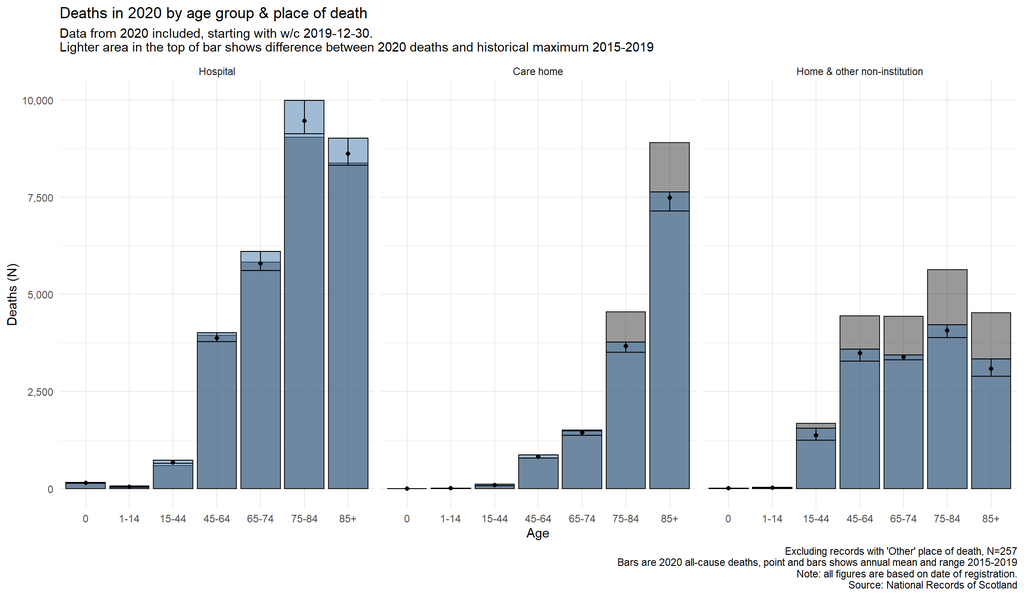

```r
bar_and_error_bars_2020_text <- "Bars are 2020 all-cause deaths, point and bars shows annual mean and range 2015-2019"
excluded_other_place_2020 <- glue::glue("Excluding records with 'Other' place of death, N={total_deaths_age %>% filter(year==2020 & place_of_death=='Other') %>% .$deaths_all_causes %>% sum}")

light_shaded_area_shows_difference <- "Lighter area in the top of bar shows difference between 2020 deaths and historical maximum 2015-2019"

# TODO: make the distinction max vs 2020 figures clearer! maybe annotate?

figure_annual_deaths_by_age_group_2020 <-
  total_deaths_age %>%
  filter(year==2020) %>%
  filter(place_of_death != "Other") %>%
  ggplot(aes(x = age, y = deaths_all_causes)) +
  # geom_col(fill = "#4477AA", alpha = 0.5, colour = "grey10") +
  geom_col(fill = "grey20", colour = "grey10", alpha = 0.5) +
  geom_col(aes(x=age, y=annual_deaths_max), fill = "#4477AA", colour = "grey10", alpha = 0.5) +  # historical maximum over the actual figure
  geom_point(aes(x=age, y=annual_deaths_mean)) +
  geom_errorbar(aes(x = age, ymin = annual_deaths_min, ymax = annual_deaths_max)) +
  facet_wrap(~place_of_death) +
  scale_y_continuous(labels = function(x) format(x,big.mark=",")) +
  theme_minimal() +
  labs(x = "Age",
       y = "Deaths (N)",
       title = "Deaths in 2020 by age group & place of death",
       subtitle = paste0(c(only_2020_text,light_shaded_area_shows_difference),collapse="\n"),
       caption = paste0(c(excluded_other_place_2020,bar_and_error_bars_2020_text,death_registrations_text,source_nrs_text), collapse="\n")
  )

walk(
  .x = c(".pdf",".svg",".png"),
  .f = ~ggsave(filename = paste0(dir_outputs,"/figure_annual_deaths_by_age_group_2020",.x), plot = figure_annual_deaths_by_age_group_2020, width = 12, height = 7, dpi = 300)
)

figure_annual_deaths_by_age_group_2020
```

## Recorded deaths in Scotland, by week number & location

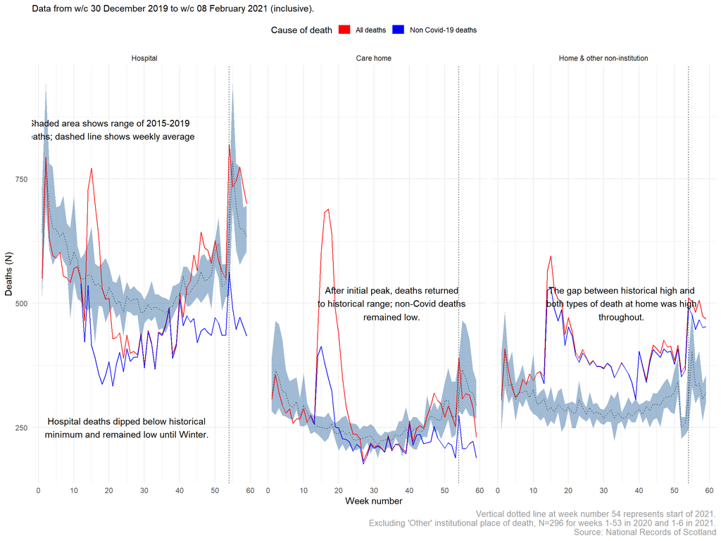

```r
removed_other_category_text <- glue::glue("Excluding 'Other' institutional place of death, N={merged_deaths_overall %>% filter(sex == 'all' & age == 'all' & place_of_death == 'Other') %>% .$deaths_all_causes %>% sum} for weeks 1-{max(merged_deaths_overall %>% filter(year==2020) %>% .$week_number)} in 2020 and 1-{max(merged_deaths_overall %>% filter(year==2021) %>% .$week_number)} in 2021.")

annotations_figure_place_of_death <-
# datapasta::tribble_paste(merged_deaths_overall %>% select(place_of_death))
  tibble::tribble(
    ~place_of_death, ~x, ~y, ~label,
                 "Hospital", 20L, 850, "Shaded area shows range of 2015-2019 deaths; dashed line shows weekly average",
                 "Hospital", 25L, 250, "Hospital deaths dipped below historical minimum and remained low until Winter.",
                "Care home", 35L, 500, "After initial peak, deaths returned to historical range; non-Covid deaths remained low.",
                     "Home & other non-institution", 35L, 500, "The gap between historical high and both types of death at home was high throughout."
                  ) %>%
  mutate(
    place_of_death = factor(place_of_death, levels = levels(merged_deaths_overall$place_of_death)),  # needs to be factor with same levels, otherwise it messes up level order when added as geom_text later!
    label = str_wrap(label, width = 40)
    )

figure_place_of_death <-
  merged_deaths_overall %>%
  filter(sex == "all" & age == "all") %>%
  filter(!place_of_death %in% c("All","Other")) %>%
  pivot_longer(cols = c(deaths_all_causes, deaths_non_covid),
               names_to = "deaths_type", values_to = "deaths") %>%
  ggplot(aes(x = week_number_run_over)) +
  geom_ribbon(aes(ymin = deaths_min, ymax = deaths_max), fill = "#4477aa", alpha = 0.5) +
  geom_line(aes(y = deaths, colour = deaths_type)) +
  geom_line(aes(y = deaths_mean), linetype = "dashed", size = 0.2) +
  geom_vline(xintercept = 54, linetype = "dotted") +
  geom_text(data = annotations_figure_place_of_death, aes(x=x,y=y, label=label)) +
  scale_x_continuous(breaks = seq(0,60,by=10)) +
  facet_grid(~place_of_death) +
  theme_minimal() +
  scale_colour_manual(values = c("red","blue"),  # custom legend for the two lines
                      labels = c("All deaths",
                                 "Non Covid-19 deaths"),
                      guide = guide_legend(label.hjust = 0.5, override.aes = list(size = 5))
                      ) +
  theme(legend.position = "top", plot.caption = element_text(size = 10, colour = "gray60")) +
  labs(x = "Week number",
       y = "Deaths (N)",
       subtitle = date_range_text,
       caption = paste0(c(vertical_line_text, removed_other_category_text, source_nrs_text), collapse="\n"),
       colour = "Cause of death"
       )

walk(
  .x = c(".pdf",".svg",".png"),
  .f = ~ggsave(filename = paste0(dir_outputs,"/figure_place_of_death",.x), plot = figure_place_of_death, width = 12, height = 9, dpi = 300)
)

figure_place_of_death
```

## All of Scotland, deaths at home

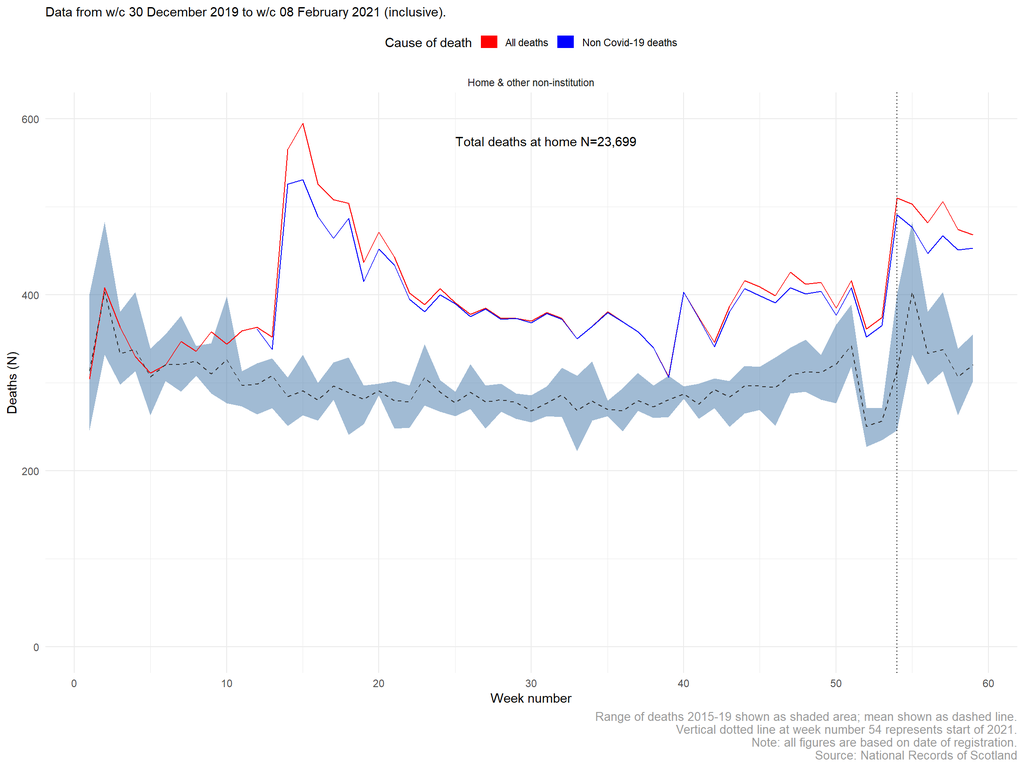

```r
# TODO: add start of lockdowns 1-3?
# TODO: what is that dip at week 38/39? not obvious - start of september was tier 4 restrictions in big LAs
total_deaths_at_home_in_period <- glue::glue("Total deaths at home N={format(merged_deaths_overall %>% filter(sex == 'all' & age == 'all' & place_of_death %in% c('Home & other non-institution')) %>% .$deaths_all_causes %>% sum, big.mark=',')}")

figure_deaths_at_home <-
  merged_deaths_overall %>%
  filter(sex == "all" & age == "all") %>%
  filter(place_of_death %in% c("Home & other non-institution")) %>%
  pivot_longer(cols = c(deaths_all_causes, deaths_non_covid),
               names_to = "deaths_type", values_to = "deaths") %>%
  ggplot(aes(x = week_number_run_over)) +
  geom_ribbon(aes(ymin = deaths_min, ymax = deaths_max), fill = "#4477aa", alpha = 0.5) +
  geom_line(aes(y = deaths, colour = deaths_type)) +
  geom_line(aes(y = deaths_mean), linetype = "dashed", colour="grey20") +
  geom_vline(xintercept = 54, linetype = "dotted") +
  scale_x_continuous(breaks = seq(0,60,by=10)) +
  ylim(0, 600) +  # start scale at 0 for better understanding the scale of deaths
  facet_grid(~place_of_death) +
  theme_minimal() +
  scale_colour_manual(values = c("red","blue"),  # custom legend for the two lines
                      labels = c("All deaths",
                                 "Non Covid-19 deaths"),
                      guide = guide_legend(label.hjust = 0.5, override.aes = list(size = 5))
                      ) +
  annotate(geom = "text", label = total_deaths_at_home_in_period, x = 25, y = 575, hjust=0) +
  theme(legend.position = "top", plot.caption = element_text(size = 10, colour = "gray60")) +
  labs(x = "Week number",
       y = "Deaths (N)",
       subtitle = date_range_text,
       caption = paste0(c(dashed_line_historical_range_text,vertical_line_text, death_registrations_text, source_nrs_text), collapse="\n"),
       colour = "Cause of death"
       )

## figure for a bit less than half A4 page is approx 14*11cm
walk(
  .x = c(".pdf",".svg",".png"),
  .f = ~ggsave(filename = paste0(dir_outputs,"/figure_deaths_at_home",.x), plot = figure_deaths_at_home, width = 14, height = 11, units = "cm", dpi = 300)
)

figure_deaths_at_home
```

## Deaths at home in 2020, all of Scotland

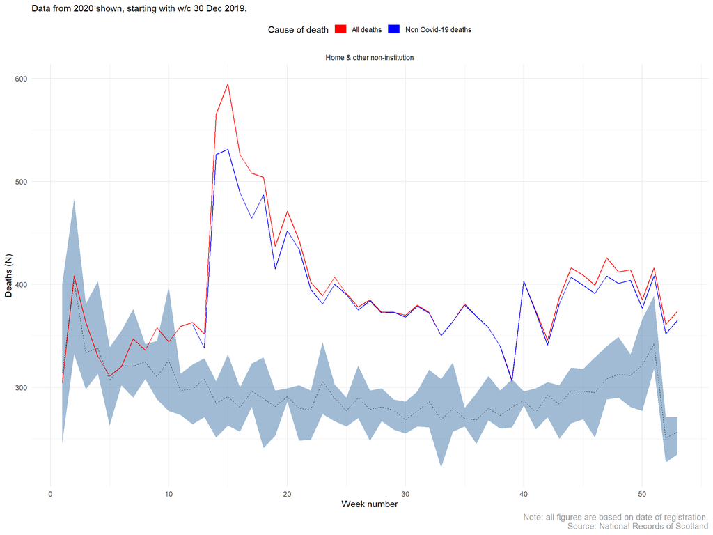

```r
figure_deaths_at_home_2020 <-
  merged_deaths_overall %>%
  filter(sex == "all" & age == "all") %>%
  filter(place_of_death %in% c("Home & other non-institution")) %>%
  filter(year == 2020) %>%
  pivot_longer(cols = c(deaths_all_causes, deaths_non_covid),
               names_to = "deaths_type", values_to = "deaths") %>%
  ggplot(aes(x = week_number_run_over)) +
  geom_ribbon(aes(ymin = deaths_min, ymax = deaths_max), fill = "#4477aa", alpha = 0.5) +
  geom_line(aes(y = deaths, colour = deaths_type)) +
  geom_line(aes(y = deaths_mean), linetype = "dashed", size = 0.2) +
  scale_x_continuous(breaks = seq(0,60,by=10)) +
  facet_grid(~place_of_death) +
  theme_minimal() +
  scale_colour_manual(values = c("red","blue"),  # custom legend for the two lines
                      labels = c("All deaths",
                                 "Non Covid-19 deaths"),
                      guide = guide_legend(label.hjust = 0.5, override.aes = list(size = 5))
                      ) +
  theme(legend.position = "top", plot.caption = element_text(size = 10, colour = "gray60")) +
  labs(x = "Week number",
       y = "Deaths (N)",
       # subtitle = date_range_text,
       subtitle = "Data from 2020 shown, starting with w/c 30 Dec 2019.",
       caption = paste0(c(death_registrations_text, source_nrs_text), collapse="\n"),
       colour = "Cause of death"
       )

walk(
  .x = c(".pdf",".svg",".png"),
  .f = ~ggsave(filename = paste0(dir_outputs,"/figure_deaths_at_home_2020",.x), plot = figure_deaths_at_home_2020, width = 12, height = 9, dpi = 300)
)

figure_deaths_at_home_2020
```

## Deaths at home, by health board

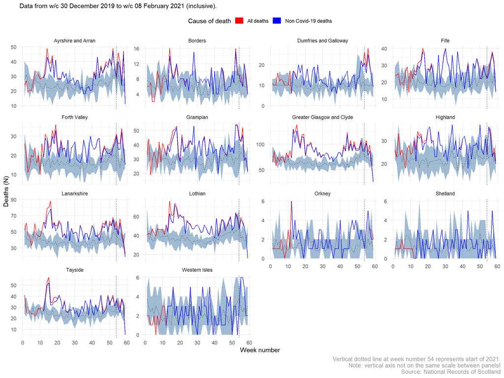

```r
island_health_boards_merged <- "Note: Orkney, Shetland, & Western health boards were merged into 'Island HBs'; Borders & Dumfries and Galloway health boards were merged into 'B,D&G HB'"
vertical_scale_differs_between_panels_text <- "Note: vertical axis not on the same scale between panels!"

figure_deaths_at_home_by_health_board <-
  merged_deaths_hb %>%
  filter(place_of_death == "Home & other non-institution") %>%
  pivot_longer(cols = c(deaths_all_causes, deaths_non_covid),
               names_to = "deaths_type", values_to = "deaths") %>%
  ggplot(aes(x = week_number_run_over)) +
  geom_ribbon(aes(ymin = deaths_min, ymax = deaths_max), fill = "#4477aa", alpha = 0.5) +
  geom_line(aes(y = deaths, colour = deaths_type)) +
  geom_line(aes(y = deaths_mean), linetype = "dashed", size = 0.2) +
  geom_vline(xintercept = 54, linetype = "dotted") +
  scale_x_continuous(breaks = seq(0,60,by=10)) +
  facet_wrap(~ref_area, scales = "free_y") +
  theme_minimal() +
  scale_colour_manual(values = c("red","blue"),  # custom legend for the two lines
                      labels = c("All deaths",
                                 "Non Covid-19 deaths"),
                      guide = guide_legend(label.hjust = 0.5, override.aes = list(size = 5))
                      ) +
  theme(legend.position = "top", plot.caption = element_text(size = 10, colour = "gray60")) +
  labs(x = "Week number",
       y = "Deaths (N)",
       subtitle = date_range_text,
       caption = paste0(c(vertical_line_text, vertical_scale_differs_between_panels_text, source_nrs_text), collapse="\n"),
       colour = "Cause of death"
       )

walk(
  .x = c(".pdf",".svg",".png"),
  .f = ~ggsave(filename = paste0(dir_outputs,"/figure_deaths_at_home_by_health_board",.x), plot = figure_deaths_at_home_by_health_board, width = 12, height = 9, dpi = 300)
)

figure_deaths_at_home_by_health_board
```

## Deaths at home with 2-week moving average, by health board

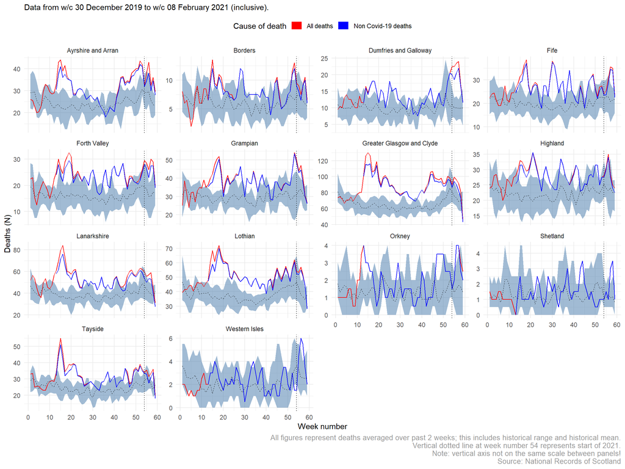

```r
moving_average_text <- "All figures represent deaths averaged over past 2 weeks; this includes historical range and historical mean."

figure_deaths_at_home_2week_average_by_health_board <-
  merged_deaths_hb %>%
  filter(place_of_death == "Home & other non-institution") %>%
  pivot_longer(cols = c(ma2w_deaths_all_causes, ma2w_deaths_non_covid),
               names_to = "deaths_type", values_to = "ma2w_deaths") %>%
  ggplot(aes(x = week_number_run_over)) +
  geom_ribbon(aes(ymin = ma2w_deaths_min, ymax = ma2w_deaths_max), fill = "#4477aa", alpha = 0.5) +
  geom_line(aes(y = ma2w_deaths, colour = deaths_type)) +
  geom_line(aes(y = ma2w_deaths_mean), linetype = "dashed", size = 0.2) +
  geom_vline(xintercept = 54, linetype = "dotted") +
  scale_x_continuous(breaks = seq(0,60,by=10)) +
  facet_wrap(~ref_area, scales = "free_y") +
  theme_minimal() +
  scale_colour_manual(values = c("red","blue"),  # custom legend for the two lines
                      labels = c("All deaths",
                                 "Non Covid-19 deaths"),
                      guide = guide_legend(label.hjust = 0.5, override.aes = list(size = 5))
                      ) +
  theme(legend.position = "top", plot.caption = element_text(size = 10, colour = "gray60")) +
  labs(x = "Week number",
       y = "Deaths (N)",
       subtitle = date_range_text,
       caption = paste0(c(moving_average_text, vertical_line_text, vertical_scale_differs_between_panels_text, source_nrs_text), collapse="\n"),
       colour = "Cause of death"
       )

walk(
  .x = c(".pdf",".svg",".png"),
  .f = ~ggsave(filename = paste0(dir_outputs,"/figure_deaths_at_home_2week_average_by_health_board",.x), plot = figure_deaths_at_home_2week_average_by_health_board, width = 12, height = 9, dpi = 300)
)

figure_deaths_at_home_2week_average_by_health_board
```

## Deaths at home, by local authority

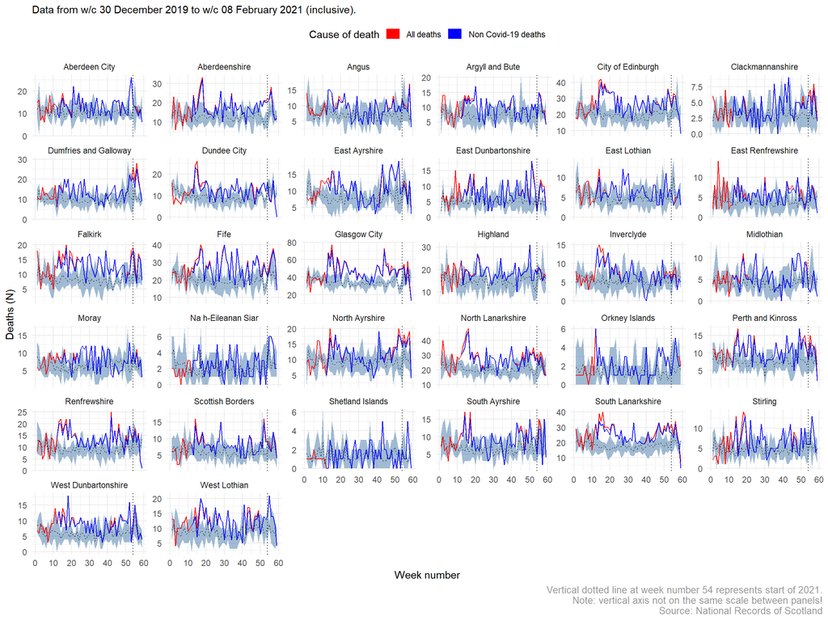

```r
figure_deaths_at_home_by_local_authority <-
  merged_deaths_la %>%
  filter(place_of_death == "Home & other non-institution") %>%
  pivot_longer(cols = c(deaths_all_causes, deaths_non_covid),
               names_to = "deaths_type", values_to = "deaths") %>%
  ggplot(aes(x = week_number_run_over)) +
  geom_ribbon(aes(ymin = deaths_min, ymax = deaths_max), fill = "#4477aa", alpha = 0.5) +
  geom_line(aes(y = deaths, colour = deaths_type)) +
  geom_line(aes(y = deaths_mean), linetype = "dashed", size = 0.2) +
  geom_vline(xintercept = 54, linetype = "dotted") +
  scale_x_continuous(breaks = seq(0,60,by=10)) +
  facet_wrap(~ref_area, scales = "free_y") +
  theme_minimal() +
  scale_colour_manual(values = c("red","blue"),  # custom legend for the two lines
                      labels = c("All deaths",
                                 "Non Covid-19 deaths"),
                      guide = guide_legend(label.hjust = 0.5, override.aes = list(size = 5))
                      ) +
  theme(legend.position = "top", plot.caption = element_text(size = 10, colour = "gray60")) +
  labs(x = "Week number",
       y = "Deaths (N)",
       subtitle = date_range_text,
       caption = paste0(c(vertical_line_text, vertical_scale_differs_between_panels_text, source_nrs_text), collapse="\n"),
       colour = "Cause of death"
       )

# merged_deaths_la %>%
#   filter(place_of_death == "Home & other non-institution") %>%
#   filter(ref_area %in% c("Moray","Highland", "Fife", "Glasgow City")) %>%
#   pivot_longer(cols = c(deaths_all_causes, deaths_non_covid),
#                names_to = "deaths_type", values_to = "deaths") %>%
#   ggplot(aes(x = week_number_run_over)) +
#   geom_ribbon(aes(ymin = deaths_min, ymax = deaths_max), fill = "#4477aa", alpha = 0.5) +
#   geom_line(aes(y = deaths, colour = deaths_type)) +
#   geom_line(aes(y = deaths_mean), linetype = "dashed", size = 0.2) +
#   geom_vline(xintercept = 54, linetype = "dotted") +
#   scale_x_continuous(breaks = seq(0,60,by=10)) +
#   facet_wrap(~ref_area, scales = "free_y", nrow = 2) +
#   theme_minimal() +
#   scale_colour_manual(values = c("red","blue"),  # custom legend for the two lines
#                       labels = c("All deaths",
#                                  "Non Covid-19 deaths"),
#                       guide = guide_legend(label.hjust = 0.5, override.aes = list(size = 5))
#                       ) +
#   theme(legend.position = "top", plot.caption = element_text(size = 10, colour = "gray60")) +
#   labs(x = "Week number",
#        y = "Deaths (N)",
#        subtitle = date_range_text,
#        caption = paste0(c(vertical_line_text, vertical_scale_differs_between_panels_text, source_nrs_text), collapse="\n"),
#        colour = "Cause of death"
#        )

walk(
  .x = c(".pdf",".svg",".png"),
  .f = ~ggsave(filename = paste0(dir_outputs,"/figure_deaths_at_home_by_local_authority",.x), plot = figure_deaths_at_home_by_local_authority, width = 12, height = 9, dpi = 300)
)

figure_deaths_at_home_by_local_authority
```

## Deaths at home with 2-week moving average, by local authority

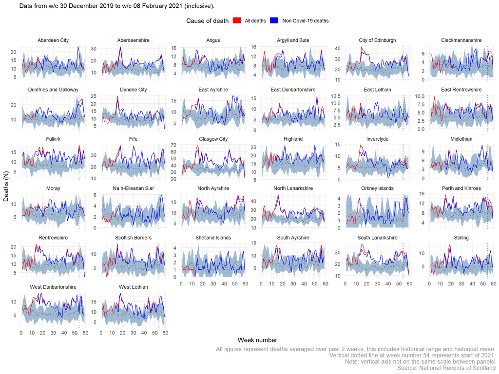

```r
figure_deaths_at_home_2week_average_by_local_authority <-
  merged_deaths_la %>%
  filter(place_of_death == "Home & other non-institution") %>%
  pivot_longer(cols = c(ma2w_deaths_all_causes, ma2w_deaths_non_covid),
               names_to = "deaths_type", values_to = "ma2w_deaths") %>%
  ggplot(aes(x = week_number_run_over)) +
  geom_ribbon(aes(ymin = ma2w_deaths_min, ymax = ma2w_deaths_max), fill = "#4477aa", alpha = 0.5) +
  geom_line(aes(y = ma2w_deaths, colour = deaths_type)) +
  geom_line(aes(y = ma2w_deaths_mean), linetype = "dashed", size = 0.2) +
  geom_vline(xintercept = 54, linetype = "dotted") +
  scale_x_continuous(breaks = seq(0,60,by=10)) +
  facet_wrap(~ref_area, scales = "free_y") +
  theme_minimal() +
  scale_colour_manual(values = c("red","blue"),  # custom legend for the two lines
                      labels = c("All deaths",
                                 "Non Covid-19 deaths"),
                      guide = guide_legend(label.hjust = 0.5, override.aes = list(size = 5))
                      ) +
  theme(legend.position = "top", plot.caption = element_text(size = 10, colour = "gray60")) +
  labs(x = "Week number",
       y = "Deaths (N)",
       subtitle = date_range_text,
       caption = paste0(c(moving_average_text, vertical_line_text, vertical_scale_differs_between_panels_text, source_nrs_text), collapse="\n"),
       colour = "Cause of death"
       )
#
# merged_deaths_la %>%
#   filter(place_of_death == "Home & other non-institution") %>%
#   filter(ref_area %in% c("Moray","Highland", "Fife", "Glasgow City")) %>%
#   pivot_longer(cols = c(deaths_all_causes, deaths_non_covid),
#                names_to = "deaths_type", values_to = "deaths") %>%
#   ggplot(aes(x = week_number_run_over)) +
#   geom_ribbon(aes(ymin = deaths_min, ymax = deaths_max), fill = "#4477aa", alpha = 0.5) +
#   geom_line(aes(y = deaths, colour = deaths_type)) +
#   geom_line(aes(y = deaths_mean), linetype = "dashed", size = 0.2) +
#   geom_vline(xintercept = 54, linetype = "dotted") +
#   scale_x_continuous(breaks = seq(0,60,by=10)) +
#   facet_wrap(~ref_area, scales = "free_y", nrow = 2) +
#   theme_minimal() +
#   scale_colour_manual(values = c("red","blue"),  # custom legend for the two lines
#                       labels = c("All deaths",
#                                  "Non Covid-19 deaths"),
#                       guide = guide_legend(label.hjust = 0.5, override.aes = list(size = 5))
#                       ) +
#   theme(legend.position = "top", plot.caption = element_text(size = 10, colour = "gray60")) +
#   labs(x = "Week number",
#        y = "Deaths (N)",
#        subtitle = date_range_text,
#        caption = paste0(c(vertical_line_text, vertical_scale_differs_between_panels_text, source_nrs_text), collapse="\n"),
#        colour = "Cause of death"
#        )

walk(
  .x = c(".pdf",".svg",".png"),
  .f = ~ggsave(filename = paste0(dir_outputs,"/figure_deaths_at_home_2week_average_by_local_authority",.x), plot = figure_deaths_at_home_2week_average_by_local_authority, width = 12, height = 9, dpi = 300)
)

figure_deaths_at_home_2week_average_by_local_authority
```

## Deaths at home by age

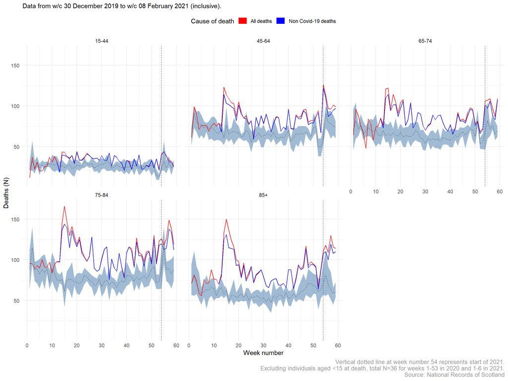

```r
removed_under_15_text <- glue::glue("Excluding individuals aged <15 at death, total N={merged_deaths_age %>% filter(age %in% c('0','1-14') & place_of_death == 'Home & other non-institution') %>% .$deaths_all_causes %>% sum} for weeks 1-{max(merged_deaths_age %>% filter(year==2020) %>% .$week_number)} in 2020 and 1-{max(merged_deaths_age %>% filter(year==2021) %>% .$week_number)} in 2021.")

figure_deaths_at_home_by_age <-
  merged_deaths_age %>%
  filter(place_of_death %in% c("Home & other non-institution")) %>%
  filter(!age %in% c('0','1-14')) %>%
  pivot_longer(cols = c(deaths_all_causes, deaths_non_covid),
               names_to = "deaths_type", values_to = "deaths") %>%
  ggplot(aes(x = week_number_run_over)) +
  geom_ribbon(aes(ymin = deaths_min, ymax = deaths_max), fill = "#4477aa", alpha = 0.5) +
  geom_line(aes(y = deaths, colour = deaths_type)) +
  geom_line(aes(y = deaths_mean), linetype = "dashed", size = 0.2) +
  geom_vline(xintercept = 54, linetype = "dotted") +
  scale_x_continuous(breaks = seq(0,60,by=10)) +
  # facet_wrap(~age, scales = "free_y") +
  facet_wrap(~age) +
  theme_minimal() +
  scale_colour_manual(values = c("red","blue"),  # custom legend for the two lines
                      labels = c("All deaths",
                                 "Non Covid-19 deaths"),
                      guide = guide_legend(label.hjust = 0.5, override.aes = list(size = 5))
                      ) +
  theme(legend.position = "top", plot.caption = element_text(size = 10, colour = "gray60")) +
  labs(x = "Week number",
       y = "Deaths (N)",
       subtitle = date_range_text,
       caption = paste0(c(vertical_line_text,removed_under_15_text, source_nrs_text), collapse="\n"),
       colour = "Cause of death"
       )

walk(
  .x = c(".pdf",".svg",".png"),
  .f = ~ggsave(filename = paste0(dir_outputs,"/figure_deaths_at_home_by_age",.x), plot = figure_deaths_at_home_by_age, width = 12, height = 9, dpi = 300)
)

figure_deaths_at_home_by_age
```

## Deaths at home by sex

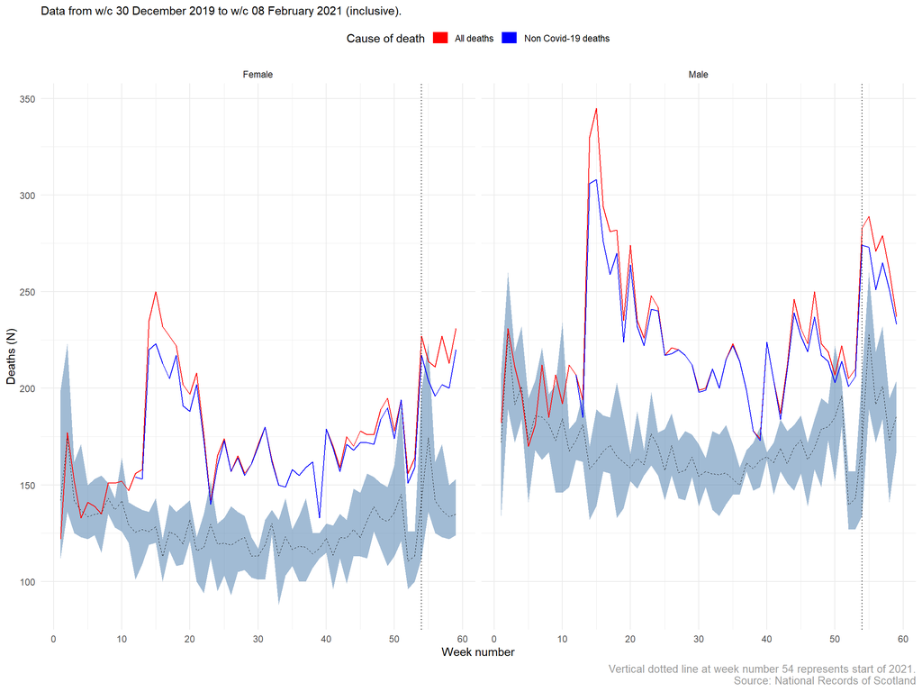

```r
figure_deaths_at_home_by_sex <-
  merged_deaths_sex %>%
  mutate(sex = if_else(sex=="F", "Female", "Male")) %>%
  filter(place_of_death %in% c("Home & other non-institution")) %>%
  pivot_longer(cols = c(deaths_all_causes, deaths_non_covid),
               names_to = "deaths_type", values_to = "deaths") %>%
  ggplot(aes(x = week_number_run_over)) +
  geom_ribbon(aes(ymin = deaths_min, ymax = deaths_max), fill = "#4477aa", alpha = 0.5) +
  geom_line(aes(y = deaths, colour = deaths_type)) +
  geom_line(aes(y = deaths_mean), linetype = "dashed", size = 0.2) +
  geom_vline(xintercept = 54, linetype = "dotted") +
  scale_x_continuous(breaks = seq(0,60,by=10)) +
  facet_grid(~sex) +
  theme_minimal() +
  scale_colour_manual(values = c("red","blue"),  # custom legend for the two lines
                      labels = c("All deaths",
                                 "Non Covid-19 deaths"),
                      guide = guide_legend(label.hjust = 0.5, override.aes = list(size = 5))
                      ) +
  theme(legend.position = "top", plot.caption = element_text(size = 10, colour = "gray60")) +
  labs(x = "Week number",
       y = "Deaths (N)",
       subtitle = date_range_text,
       caption = paste0(c(vertical_line_text, source_nrs_text), collapse="\n"),
       colour = "Cause of death"
       )

walk(
  .x = c(".pdf",".svg",".png"),
  .f = ~ggsave(filename = paste0(dir_outputs,"/figure_deaths_at_home_by_sex",.x), plot = figure_deaths_at_home_by_sex, width = 12, height = 9, dpi = 300)
)

figure_deaths_at_home_by_sex
```

## Overall deaths at home 2020 by cause of death

```r
# TODO: add yearly range for all deaths
# TODO: split data by covid-underlying cause of desath & covid-factor in death
merged_deaths_overall %>%
  filter(sex=="all", age=="all") %>%
  filter(year==2020) %>%
  filter(place_of_death == "Home & other non-institution") %>%
  group_by(ref_area, year) %>%
  summarise(
    deaths_all_causes = sum(deaths_all_causes, na.rm=TRUE),
    deaths_covid_related = sum(deaths_covid_related, na.rm=TRUE),
    deaths_non_covid = sum(deaths_non_covid, na.rm=TRUE)
  )
```

[output not shown]

# Case counts & home deaths - comparing plots

## Scotland-wide figure

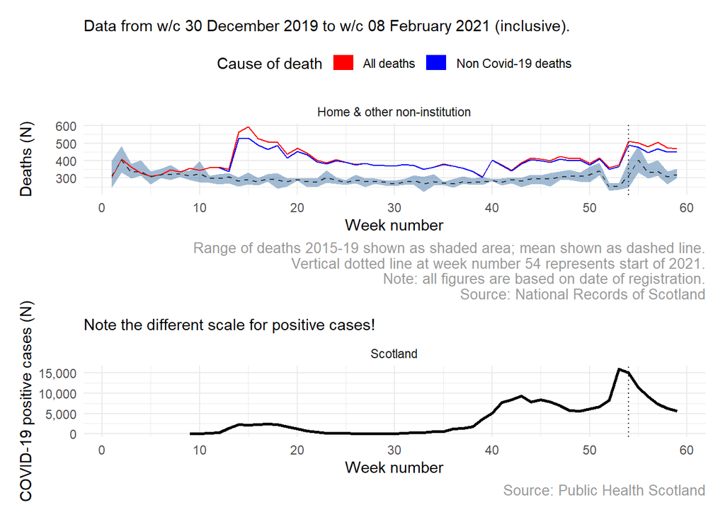

```r
# TODO: wokr out how to include both... two panels? two axes on same plot?

ratio_max_weekly_deaths_to_cases <- 600 / 16e3


figure_weekly_deaths_to_cases_part_1 <-
  merged_deaths_overall %>%
  filter(sex=="all" & age=="all" & str_starts(place_of_death, "Home")) %>%
  left_join(weekly_covid_cases_overall, by=c("year","week_number","date_w_c","week_number_run_over","ref_area")) %>%
  pivot_longer(cols = c(deaths_all_causes, deaths_non_covid),
               names_to = "deaths_type", values_to = "deaths") %>%
  ggplot(aes(x = week_number_run_over)) +
  geom_ribbon(aes(ymin = deaths_min, ymax = deaths_max), fill = "#4477aa", alpha = 0.5) +
  geom_line(aes(y = deaths, colour = deaths_type)) +
  geom_line(aes(y = deaths_mean), linetype = "dashed", colour="grey20") +
  # geom_line(aes(y = weekly_positive * ratio_max_weekly_deaths_to_cases), colour="purple") +
  geom_vline(xintercept = 54, linetype = "dotted") +
  scale_x_continuous(breaks = seq(0,60,by=10)) +
  # scale_y_continuous(sec.axis = sec_axis(trans = ~./ratio_max_weekly_deaths_to_cases, name = "Weekly cases")) +
  # ylim(0, 600) +  # start scale at 0 for better understanding the scale of deaths
  facet_grid(~place_of_death) +
  theme_minimal() +
  scale_colour_manual(values = c("red","blue"),  # custom legend for the two lines
                      labels = c("All deaths",
                                 "Non Covid-19 deaths"),
                      guide = guide_legend(label.hjust = 0.5, override.aes = list(size = 5))
                      ) +
  # annotate(geom = "text", label = total_deaths_at_home_in_period, x = 25, y = 575, hjust=0) +
  theme(legend.position = "top", plot.caption = element_text(size = 10, colour = "gray60")) +
  labs(x = "Week number",
       y = "Deaths (N)",
       subtitle = date_range_text,
       caption = paste0(c(dashed_line_historical_range_text,vertical_line_text, death_registrations_text, source_nrs_text), collapse="\n"),
       colour = "Cause of death"
       )

figure_weekly_deaths_to_cases_part_2 <-
  merged_deaths_overall %>%
  filter(sex=="all" & age=="all" & str_starts(place_of_death, "Home")) %>%
  left_join(weekly_covid_cases_overall, by=c("year","week_number","date_w_c","week_number_run_over","ref_area")) %>%
  ggplot(aes(x=week_number_run_over, y=weekly_positive)) +
  geom_line(size=1) +
  geom_vline(xintercept = 54, linetype = "dotted") +
  theme_minimal() +
  facet_grid(~ref_area) +
  theme(legend.position = "top", plot.caption = element_text(size = 10, colour = "gray60")) +
  scale_x_continuous(breaks = seq(0,60,by=10)) +
  scale_y_continuous(labels = function(x) format(x, big.mark=",")) +
  labs(
    x = "Week number", y = "COVID-19 positive cases (N)",
    subtitle = "Note the different scale for positive cases!",
    caption = paste0(c(source_phs_text), collapse="\n")
  )

figure_weekly_deaths_to_cases <- wrap_plots(figure_weekly_deaths_to_cases_part_1,figure_weekly_deaths_to_cases_part_2, ncol = 1)

## figure for a bit less than half A4 page is approx 14*11cm
walk(
  .x = c(".pdf",".svg",".png"),
  .f = ~ggsave(filename = paste0(dir_outputs,"/figure_weekly_deaths_to_cases",.x), plot = figure_weekly_deaths_to_cases, width = 15, height = 15, units = "cm", dpi = 300)
)
figure_weekly_deaths_to_cases
```

# Map-based visualisations

## Ratio of 2020 home deaths to historical home deaths by LA / HB

```r
areas_relatively_higher_number_home_deaths_text <- "Lighter areas represent areas with relatively higher number of home deaths in 2020 compared to historical mean"
home_deaths_ratio_text <- "Ratio computed from total home deaths in 2020 divided by mean annual home deaths 2015-2019"

## max/min used for setting scale of fill colour so it's consistent between plots!
maximum_ratio_between_hb_and_la_home_deaths <-
  bind_rows(
    total_deaths_la,
    total_deaths_hb
  ) %>%
  filter(year==2020 & place_of_death == "Home & other non-institution") %>%
  .$ratio_annual_deaths_to_historical_mean %>%
  max

minimum_ratio_between_hb_and_la_home_deaths <-
  bind_rows(
    total_deaths_la,
    total_deaths_hb
  ) %>%
  filter(year==2020 & place_of_death == "Home & other non-institution") %>%
  .$ratio_annual_deaths_to_historical_mean %>%
  min %>%
  round(digits=1)
```

### LA

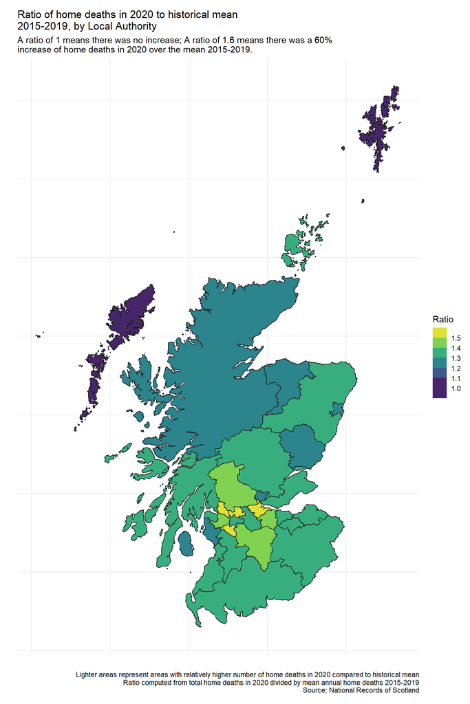

```r
# TODO: work out the size of these plots
figure_map_ratio_home_deaths_2020_to_historical_la <-
  total_deaths_la %>%
  filter(
    year == 2020 & place_of_death == "Home & other non-institution"
  ) %>%
  left_join(shapefile_la, by=c("ref_area"="LAD20NM")) %>%
  ggplot(aes(geometry=geometry, fill=ratio_annual_deaths_to_historical_mean), colour="grey10") +
  geom_sf(colour="grey10") +
  scale_fill_viridis_b(limits = c(minimum_ratio_between_hb_and_la_home_deaths, maximum_ratio_between_hb_and_la_home_deaths)) +
  theme_minimal() +
  theme(axis.text = element_blank()) +
  labs(x="", y="",
       title = str_wrap("Ratio of home deaths in 2020 to historical mean 2015-2019, by Local Authority", width = 50),
       subtitle = str_wrap("A ratio of 1 means there was no increase; A ratio of 1.6 means there was a 60% increase of home deaths in 2020 over the mean 2015-2019.", width = 80),
       caption = paste0(c(areas_relatively_higher_number_home_deaths_text, home_deaths_ratio_text, source_nrs_text), collapse="\n"),
       fill = "Ratio"
       ) +
  NULL


walk(
  .x = c(".pdf",".svg",".png"),
  .f = ~ggsave(filename = paste0(dir_outputs,"/figure_map_ratio_home_deaths_2020_to_historical_la",.x), plot = figure_map_ratio_home_deaths_2020_to_historical_la, width = 9, height = 12, dpi = 300)
)

figure_map_ratio_home_deaths_2020_to_historical_la
```

### HB

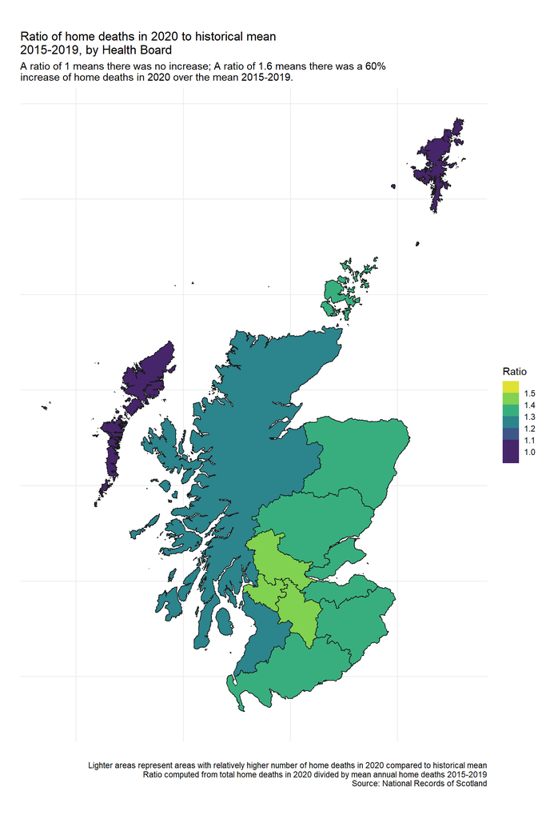

```r
# TODO: work out the size of these plots
figure_map_ratio_home_deaths_2020_to_historical_hb <-
  total_deaths_hb %>%
  filter(
    year == 2020 & place_of_death == "Home & other non-institution"
  ) %>%
  left_join(shapefile_hb_uk_wide, by=c("ref_area"="name")) %>%
  ggplot(aes(geometry=geometry, fill=ratio_annual_deaths_to_historical_mean), colour="grey10") +
  geom_sf(colour="grey10") +
  scale_fill_viridis_b(limits = c(minimum_ratio_between_hb_and_la_home_deaths, maximum_ratio_between_hb_and_la_home_deaths)) +
  theme_minimal() +
  theme(axis.text = element_blank(), aspect.ratio = 1.4) +
  labs(x="", y="",
       title = str_wrap("Ratio of home deaths in 2020 to historical mean 2015-2019, by Health Board", width=50),
       subtitle = str_wrap("A ratio of 1 means there was no increase; A ratio of 1.6 means there was a 60% increase of home deaths in 2020 over the mean 2015-2019.", width = 80),
       caption = paste0(c(areas_relatively_higher_number_home_deaths_text, home_deaths_ratio_text, source_nrs_text), collapse="\n"),
       fill = "Ratio"
       ) +
  NULL


walk(
  .x = c(".pdf",".svg",".png"),
  .f = ~ggsave(filename = paste0(dir_outputs,"/figure_map_ratio_home_deaths_2020_to_historical_hb",.x), plot = figure_map_ratio_home_deaths_2020_to_historical_hb, width = 9, height = 12, dpi = 300)
)

figure_map_ratio_home_deaths_2020_to_historical_hb
```

## Per capita cases of COVID-19 by region

```r
areas_relatively_higher_number_cases <- "Lighter areas represent areas with relatively higher number of COVID-19 cases per 100,000 population in 2020"
```

### LA

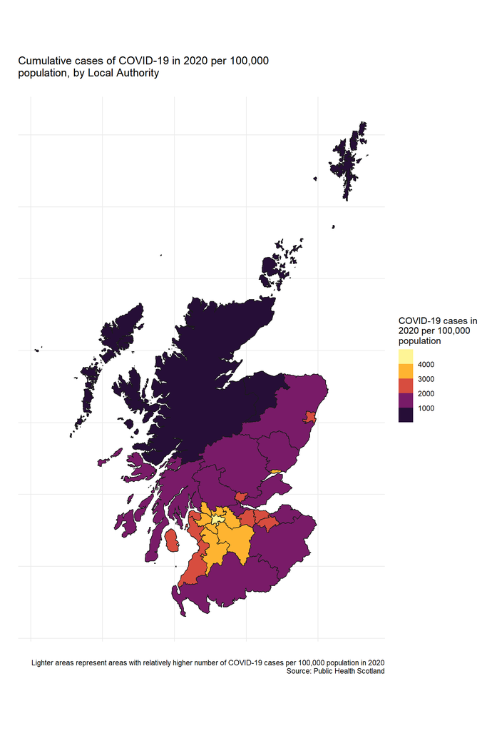

```r
figure_map_per_capita_covid_cases_2020_la <-
  weekly_covid_cases_la %>%
  filter(year == 2020 & week_number == 53) %>%
  left_join(shapefile_la, by=c("ref_area"="LAD20NM")) %>%
  ggplot(aes(geometry=geometry, fill=crude_rate_positive_per100k), colour="grey10") +
  geom_sf(colour="grey10") +
  scale_fill_viridis_b(option = "B") +
  theme_minimal() +
  theme(axis.text = element_blank()) +
  labs(x="", y="",
       title = str_wrap("Cumulative cases of COVID-19 in 2020 per 100,000 population, by Local Authority",width=50),
       subtitle = "",
       caption = paste0(c(areas_relatively_higher_number_cases, source_phs_text), collapse="\n"),
       fill = str_wrap("COVID-19 cases in 2020 per 100,000 population", width = 20)
       ) +
  NULL


walk(
  .x = c(".pdf",".svg",".png"),
  .f = ~ggsave(filename = paste0(dir_outputs,"/figure_map_per_capita_covid_cases_2020_la",.x), plot = figure_map_per_capita_covid_cases_2020_la, width = 9, height = 12, dpi = 300)
)

figure_map_per_capita_covid_cases_2020_la
```

### HB

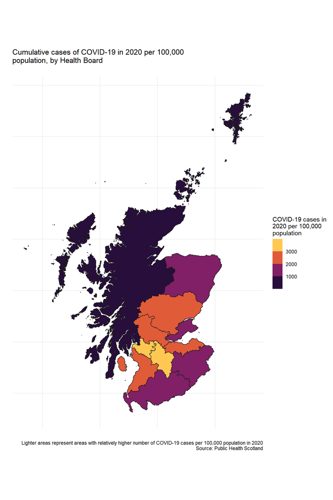

```r
figure_map_per_capita_covid_cases_2020_hb <-
  weekly_covid_cases_hb %>%
  filter(year == 2020 & week_number == 53) %>%
  left_join(shapefile_hb_uk_wide, by=c("ref_area"="name")) %>%
  ggplot(aes(geometry=geometry, fill=crude_rate_positive_per100k), colour="grey10") +
  geom_sf(colour="grey10") +
  scale_fill_viridis_b(option = "B") +
  theme_minimal() +
  theme(axis.text = element_blank(), aspect.ratio = 1.4) +
  labs(x="", y="",
       title = str_wrap("Cumulative cases of COVID-19 in 2020 per 100,000 population, by Health Board",width=50),
       subtitle = "",
       caption = paste0(c(areas_relatively_higher_number_cases, source_phs_text), collapse="\n"),
       fill = str_wrap("COVID-19 cases in 2020 per 100,000 population", width = 20)
       ) +
  NULL


walk(
  .x = c(".pdf",".svg",".png"),
  .f = ~ggsave(filename = paste0(dir_outputs,"/figure_map_per_capita_covid_cases_2020_hb",.x), plot = figure_map_per_capita_covid_cases_2020_hb, width = 9, height = 12, dpi = 300)
)

figure_map_per_capita_covid_cases_2020_hb
```